# QCIRMS Tutorial: QA/QC Workflow for Continuous-Flow IRMS DXF Files

Brett McKinney

Lily Clough

March 22, 2026

# 1 Overview

This tutorial walks through a practical QCIRMS workflow for continuous-flow isotope ratio mass spectrometry (IRMS) data stored in Thermo `.dxf` files. It is adapted from the package pipeline script and reorganized as a reproducible R Markdown analysis.

The workflow has four parts:

1. install and load dependencies;
2. inspect a single `.dxf` file;
3. process a directory of files and generate chromatogram plots;
4. run the `QAQC_IRMS()` directory-level QA/QC workflow.

# 2 Installation

QCIRMS currently depends on `isoreader`, which is installed from GitHub.

```r
install.packages(c("dplyr", "pracma"))
install.packages("pak")

pak::pak("isoverse/isoreader")
pak::pak("insilico/QCIRMS")
```

# 3 Load packages

```r
library(QCIRMS)
library(isoreader)
library(dplyr)
library(pracma)
```

# 4 Example 1: Inspect one packaged DXF file

QCIRMS ships with a small example DXF file in `inst/extdata`.

```r
dxf_file <- "170506_NaHCO3 L + NaCl U_.dxf"
file_path <- system.file("extdata", "dxf_files", "abiotic", dxf_file, package = "QCIRMS")

file_path
```

```
## [1] "/Library/Frameworks/R.framework/Versions/4.1/Resources/library/QCIRMS/extdata/dxf_files/abiotic/170506_NaHCO3 L + NaCl U_.dxf"
```

## 4.1 Read the file summary

```r
file_summ <- read_summary(file_path)
```

```
##                   Length Class           Mode
## version            1     package_version list
## read_options       4     -none-          list
## file_info         16     tbl_df          list
## method_info        3     -none-          list
## raw_data           5     tbl_df          list
## vendor_data_table 39     tbl_df          list
```

```r
str(file_summ, max.level = 1)
```

```
##  'summaryDefault' chr [1:6, 1:3] " 1" " 4" "16" " 3" " 5" "39" ...
##  - attr(*, "dimnames")=List of 2
```

## 4.2 Vendor peak table

```r
vend_df <- vendor_info(file_path)
dplyr::glimpse(vend_df)
```

```
## Rows: 17
## Columns: 40
## $ file_id           <chr> "170506_NaHCO3 L + NaCl U_.dxf", "170506_NaHCO3 L + …
## $ Nr.               <int> 1, 2, 3, 4, 5, 6, 7, 8, 9, 10, 11, 12, 13, 14, 15, 1…
## $ Start             <dbl[s]> 27.170, 66.880, 131.043, 166.364, 206.492, 270.44…
## $ Rt                <dbl[s]> 47.443, 87.153, 133.551, 186.637, 226.556, 274.62…
## $ End               <dbl[s]> 50.787, 90.497, 140.030, 189.981, 229.900, 280.26…
## $ `Ampl 44`         <dbl[mV]> 2425.98279, 2425.01937, 3592.12560, 2425.83698, …
## $ `Ampl 45`         <dbl[mV]> 2788.82883, 2787.82824, 4210.89010, 2788.40579, …
## $ `Ampl 46`         <dbl[mV]> 3307.89559, 3306.34882, 4936.99954, 3307.00156, …
## $ `BGD 44`          <dbl[mV]> 1.207758, 1.599683, 1.429455, 1.570985, 1.663159…
## $ `BGD 45`          <dbl[mV]> 0.5735142, 0.9146100, 0.7790426, 0.9509011, 1.10…
## $ `BGD 46`          <dbl[mV]> 2.175937, 2.696454, 2.514959, 2.514959, 2.817206…
## $ `rIntensity 44`   <dbl[mVs]> 47197.497, 47201.849, 5554.191, 47221.290, 4696…
## $ `rIntensity 45`   <dbl[mVs]> 54257.8261, 54260.9364, 6496.6322, 54283.1313, …
```

[output cut: 27 more lines]

```r
head(vend_df[, 1:min(10, ncol(vend_df))])
```

|  | file_id | Nr. | Start | Rt | End | Ampl 44 | Ampl 45 | Ampl 46 | BGD 44 | BGD 45 |
| --- | --- | --- | --- | --- | --- | --- | --- | --- | --- | --- |
| 1 | 170506_NaHCO3 L + NaCl U_.dxf | 1 | 27.170 | 47.443 | 50.787 | 2425.983 | 2788.829 | 3307.896 | 1.207758 | 0.5735142 |
| 2 | 170506_NaHCO3 L + NaCl U_.dxf | 2 | 66.880 | 87.153 | 90.497 | 2425.019 | 2787.828 | 3306.349 | 1.599683 | 0.9146100 |
| 3 | 170506_NaHCO3 L + NaCl U_.dxf | 3 | 131.043 | 133.551 | 140.030 | 3592.126 | 4210.890 | 4937.000 | 1.429455 | 0.7790426 |
| 4 | 170506_NaHCO3 L + NaCl U_.dxf | 4 | 166.364 | 186.637 | 189.981 | 2425.837 | 2788.406 | 3307.002 | 1.570985 | 0.9509011 |
| 5 | 170506_NaHCO3 L + NaCl U_.dxf | 5 | 206.492 | 226.556 | 229.900 | 2432.543 | 2796.017 | 3316.630 | 1.663159 | 1.1018519 |
| 6 | 170506_NaHCO3 L + NaCl U_.dxf | 6 | 270.446 | 274.626 | 280.269 | 5976.789 | 6989.818 | 8451.918 | 1.446664 | 0.8344063 |

## 4.3 Raw chromatogram data

```r
raw_df <- raw_data(file_path)
dplyr::glimpse(raw_df)
```

```
## Rows: 4,298
## Columns: 6
## $ file_id <chr> "170506_NaHCO3 L + NaCl U_.dxf", "170506_NaHCO3 L + NaCl U_.dx…
## $ tp      <int> 1, 2, 3, 4, 5, 6, 7, 8, 9, 10, 11, 12, 13, 14, 15, 16, 17, 18,…
## $ time.s  <dbl> 0.209, 0.418, 0.627, 0.836, 1.045, 1.254, 1.463, 1.672, 1.881,…
## $ v44.mV  <dbl> 1.128612, 1.130524, 1.117143, 1.117143, 1.124789, 1.113320, 1.…
## $ v45.mV  <dbl> 0.4017511, 0.3998433, 0.4208301, 0.3941199, 0.4151062, 0.41319…
## $ v46.mV  <dbl> 2.038189, 1.996066, 1.942465, 1.942465, 1.927152, 1.967350, 2.…
```

```r
head(raw_df)
```

|  | file_id | tp | time.s | v44.mV | v45.mV | v46.mV |
| --- | --- | --- | --- | --- | --- | --- |
| 1 | 170506_NaHCO3 L + NaCl U_.dxf | 1 | 0.209 | 1.128612 | 0.4017511 | 2.038189 |
| 2 | 170506_NaHCO3 L + NaCl U_.dxf | 2 | 0.418 | 1.130524 | 0.3998433 | 1.996066 |
| 3 | 170506_NaHCO3 L + NaCl U_.dxf | 3 | 0.627 | 1.117143 | 0.4208301 | 1.942465 |
| 4 | 170506_NaHCO3 L + NaCl U_.dxf | 4 | 0.836 | 1.117143 | 0.3941199 | 1.942465 |
| 5 | 170506_NaHCO3 L + NaCl U_.dxf | 5 | 1.045 | 1.124789 | 0.4151062 | 1.927152 |
| 6 | 170506_NaHCO3 L + NaCl U_.dxf | 6 | 1.254 | 1.113320 | 0.4131983 | 1.967350 |

## 4.4 Reference values

```r
stand_ratio_df <- reference_values_ratio(file_path)
stand_no_ratio_df <- reference_values_no_ratio(file_path)

head(stand_ratio_df)
```

|  | file_id | standard | gas | delta_name | delta_value | reference | element | ratio_name | ratio_value |
| --- | --- | --- | --- | --- | --- | --- | --- | --- | --- |
| 1 | 170506_NaHCO3 L + NaCl U_.dxf | CO2_zero | CO2 | d 13C/12C | -36.9 | VPDB | C | R 13C/12C | 0.01118020 |
| 2 | 170506_NaHCO3 L + NaCl U_.dxf | CO2_zero | CO2 | d 13C/12C | -36.9 | VPDB | O | R 18O/16O | 0.00206720 |
| 3 | 170506_NaHCO3 L + NaCl U_.dxf | CO2_zero | CO2 | d 13C/12C | -36.9 | VPDB | O | R 17O/16O | 0.00038600 |
| 4 | 170506_NaHCO3 L + NaCl U_.dxf | CO2_zero | CO2 | d 18O/16O | -40.0 | VSMOW | H | R 2H/1H | 0.00015575 |
| 5 | 170506_NaHCO3 L + NaCl U_.dxf | CO2_zero | CO2 | d 18O/16O | -40.0 | VSMOW | O | R 17O/16O | 0.00037990 |
| 6 | 170506_NaHCO3 L + NaCl U_.dxf | CO2_zero | CO2 | d 18O/16O | -40.0 | VSMOW | O | R 18O/16O | 0.00200520 |

```r
head(stand_no_ratio_df)
```

|  | file_id | standard | gas | delta_name | delta_value | reference |
| --- | --- | --- | --- | --- | --- | --- |
| 1 | 170506_NaHCO3 L + NaCl U_.dxf | CO2_zero | CO2 | d 13C/12C | -36.9 | VPDB |
| 2 | 170506_NaHCO3 L + NaCl U_.dxf | CO2_zero | CO2 | d 18O/16O | -40.0 | VSMOW |

## 4.5 Plot one chromatogram

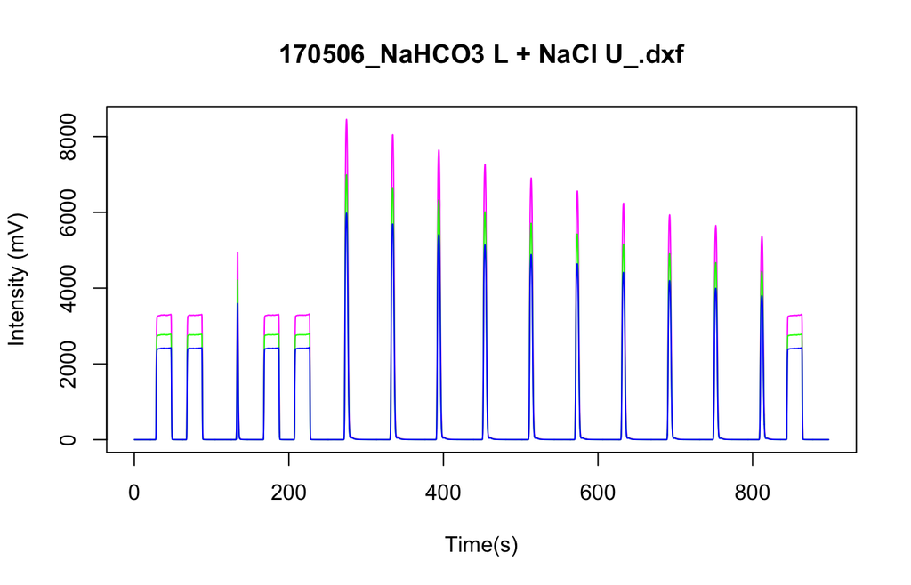

```r
generic_raw_plot(
  raw.df = raw_df,
  title = dxf_file
)
```

# 5 Example 2: Batch processing for a directory of DXF files

For a local experiment directory, set `data_dir` to a folder containing `.dxf` files. If you knit this document without parameters, the chunk below is skipped.

```r
DATA_PATH <- params$data_dir
RESULTS_PATH <- params$results_dir

if (is.null(RESULTS_PATH) && !is.null(DATA_PATH)) {
  RESULTS_PATH <- file.path(DATA_PATH, "QCresults")
  dir.create(RESULTS_PATH, recursive = TRUE, showWarnings = FALSE)
}
```

```r
file_names <- all_dxf_files(path = DATA_PATH)
length(file_names)
head(file_names)

raw_list <- raw_data_all(file_names, path = DATA_PATH)
length(raw_list)
```

```r
generic_plot_all_raw(
  raw.list = raw_list,
  path = RESULTS_PATH,
  write_pdf = TRUE,
  pdf_name = "all_dxf.pdf"
)
```

# 6 Example 3: Directory-level QA/QC with expected reference times

To run the full pipeline you need:

- a directory of `.dxf` files;
- a table of expected reference-peak times, for example `referencePeaks_expectedTimes.txt`;
- an output directory for results.

```r
REF_TIME_FILE <- params$ref_time_file

if (!is.null(REF_TIME_FILE)) {
  expRef_df <- read.table(REF_TIME_FILE, header = TRUE)
  expRef_df
}
```

## 6.1 Run `QAQC_IRMS()`

```r
start_time <- Sys.time()

curr_filtered <- QAQC_IRMS(
  unfilteredPath = DATA_PATH,
  expRef.df = expRef_df,
  checkIntStand = TRUE,
  internalStandID = c("L1", "H1", "LW"),
  dataName = basename(DATA_PATH),
  maxPkNum = 18,
  expectedNonSampPks = 7,
  sdCrefIso.thresh = 0.1,
  sdOrefIso.thresh = 0.1,
  checkRelDiffIntensity = TRUE,
  refSamp_relDiffInt.thresh = 0.75,
  amplName = "Ampl44",
  ref_relDiffInt.thresh = 0.1,
  sdCsampIso.thresh = 0.3,
  sdOsampIso.thresh = 0.2,
  outPath = RESULTS_PATH,
  verbose = TRUE
)

elapsed <- Sys.time() - start_time
elapsed
```

## 6.2 Extract QA/QC outputs

```r
refs_dat <- curr_filtered[[1]]
samps_dat <- curr_filtered[[2]]

dim(refs_dat)
dim(samps_dat)

head(refs_dat)
head(samps_dat)
```

## 6.3 Internal standards (optional)

```r
int_stand_list <- curr_filtered[[3]]

length(int_stand_list)
str(int_stand_list, max.level = 1)
```

# 7 Suggested next steps

- Add this tutorial as a package vignette under `vignettes/`.
- Replace any hard-coded paths with `params` or `here::here()`.
- Keep only small demonstration files in `inst/extdata/`.
- Store larger local data outside the installed package and document the expected directory structure.